# Classificazione delle università nel mondo

Alessia Bressan

2022-07-02

# Introduzione

Ogni anno le diverse università del mondo vengono classificante in base a diversi criteri specifici dell’organizzazione che svolge l’analisi Tra di loro vengono analizzati i dati riferiti alle classifiche più importanti e/o conosciute:

- QS World University Rankings
- Centre for World University Rankings (CWUR)
- Academic Ranking of World Universities (ARWU)
- Times Higher Education World University Ranking

## QS World University Rankings

Il QS World University Rankings è una classifica mondiale di università pubblicata ogni anno dalla società Quacquarelli Symonds Il punteggio rilasciato dal QS World University Rankings si basa sui seguenti punti:

1. **Academic reputation**, che tiene conto della qualità dell’insegnamento e ricerca universitaria
2. **Employer Reputation**, che tiene conto della preparazione degli studenti per il mondo del lavoro
3. **Faculty/Student Ratio**, rappresenta il numero di docenti per studenti, cioè la facilità con cui le istituzioni forniscono agli studenti l’accesso a docenti e/o tutor
4. **Citations per faculty**, indica la misura della qualità di ricerca universitaria, considerando il numero totale di citazioni accademiche nei documenti prodotti dall’università negli ultimi cinque anni
5. **International Faculty Ratio**, indica il rapporto tra docenti stranieri e non all’interno dell’università
6. **International Student Ratio**, indica il rapporto tra studenti stranieri e non all’interno dell’università

## Centre for World University Rankings (CWUR)

Il Center for World University Rankings (CWUR) è un’organizzazione che dal 2012 pubblica una classifica accademica delle università globali Nasce come un progetto a Jeddah, in Arabia Saudita, con l’obiettivo di classificare le prime 100 università del mondo, dal 2019, la classifica si è ampliata per elencare le prime 2000 università mondiali, rendendola la più grande classifica accademica delle università globali La classificazione si basa sui seguenti punti:

1. **Education**, tiene conto del successo accademico degli studenti di un’università e misurata dal numero degli studenti che hanno ottenuto prestigiosi riconoscimenti accademici rispetto alle dimensioni dell’università stessa
2. **Employability**,tiene conto del successo professionale degli studenti ed è misurata dal loro numero che hanno ricoperto posizioni apicali in importanti aziende rispetto alle dimensioni dell’università
3. **Faculty**, indica il numero di docenti che hanno vinto prestigiosi riconoscimenti accademici
4. **Research**, indica la ricerca, che è a sua volta divisa in quattro indicatori:
   - **Research Output**, indica il numero totale di articoli di ricerca
   - **High-Quality Publications**, indica il numero di articoli di ricerca pubblicati sulle maggiori riviste
   - **Influence**, indica il numero di articoli di ricerca pubblicati su riviste di maggiore influenza
   - **Citations**, indica il numero di articoli di ricerca altamente citati

## Academic Ranking of World Universities (ARWU)

L’Academic Ranking of World Universities (ARWU) nasce nel 2003 dal Center for World-Class Universities (CWCU), Graduate School of Education (ex Institute of Higher Education) dell’Università Jiao Tong di arwu e da allora viene aggiornato su su base annua Dal 2009 la classifica viene pubblicata dal arwuRanking Consultancy, classificando oltre 2500 università, ma solo le prime 1000 vengono pubblicate La classificazione si basa sui seguenti punti:

1. **Quality of Education**, tiene conto degli alumni che hanno conseguito il Premio Nobel e/o la Medaglia Fields
2. **Quality of Faculty**, considera due indicatori:
   - **Award**, indica lo staff che ha conseguito il Premio Nobel e/o la Medaglia Fields
   - **HiCi**, indica il numero delle ricerche maggiormente citate
3. **Research Output**, considera due indicatori:
   - **N&S**, indica il numero di ricerche pubblicate sulla rivista Nature e Science
   - **PUB**, indica tutte le pubblicazioni indicizzate in Science Citation Index-Expanded e Social Science Citation Index
4. **Per Capita Performance**, indica lo score ponderato dei precedenti indicatori diviso per il numero dello staff accademico

## Times Higher Education World University Ranking

Il Times Higher Education World University Rankings è una pubblicazione annuale delle classifiche universitarie della rivista Times Higher Education (THE), dal 2004 la rivista collaborava con Quacquarelli Symonds (QS) per pubblicare la classifica congiunta THE-QS World University, ma dal 2010 la collaborazione cessa e le classifiche successive vengono stilate con l’aiuto di Thomson Reuters, una società canadese, mentre dal 2014 la THE collabora con l’Elsevier, una casa editrice olandese La classifica presenta ben 13 indicatori divisi in 5 aree:

1. **Teaching**, si tratta dell’analisi dell’ambiente di apprendimento in cui sono presenti gli studenti, viene analizzato tramite la reputazione dell’università (**Reputation survey**), il rapporto staff/studenti (**Staff-to-student ratio**), ma anche tra dottorati e laureati (**Doctorate-to-bachelor’s ratio**) e il personale accademico (**Doctorates-awarded-to-academic-staff ratio**), infine viene considerato il reddito istituzionale (**Institutional income**)
2. **Research**, si tratta dell’analisi della ricerca svolta dall’università analizzandone la reputazione (**reputation survey**), reddito (**research income**) e volume (**research productivity**) della stessa
3. **Citations**, si tratta dell’analisi dell’influenza della ricerca, in cui viene esaminato il ruolo dell’università a diffondere nuove conoscenze e idee
4. **Industry income**, si tratta dell’analisi del rapporto tra università e industria, analizzando la capacità della prima di innovare e trasferire conoscenze alla seconda
5. **International outlook**, si tratta dell’analisi della capacità di un’università di attrarre studenti (**proportion of international students**) e personale internazionale (**proportion of international staff**), nonchè la loro collaborazione internazionale (**international collaboration**)

## Diverse classifiche, diversi indicatori e diversi pesi

Nonostante le classifiche analizzino tutte la qualità dell’insegnamento, ricerca, rapporti tra studenti e staff, e in alcuni la valutazione della presenza internazionale all’interno di un’università, ogni classifica presenta indicatori diversi come i loro pesi nel punteggio finale:

- QS World University Rankings

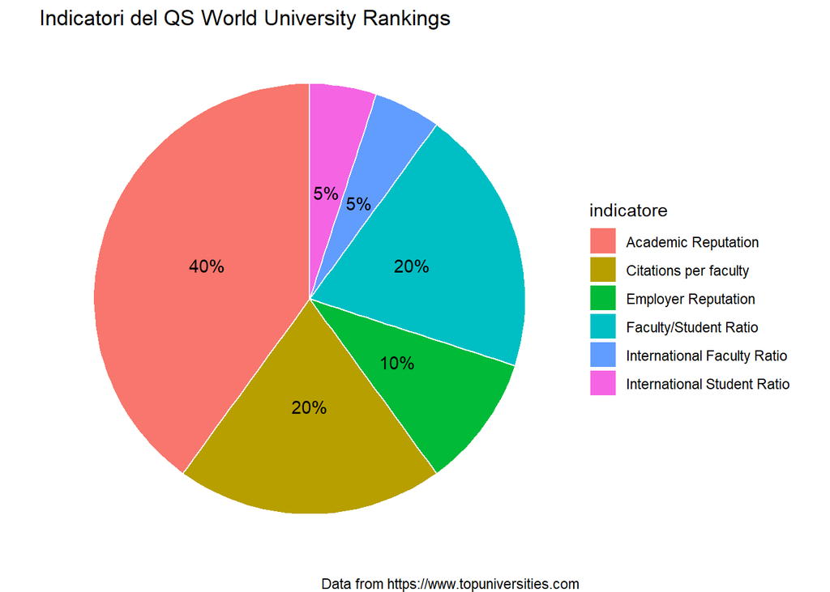

- Centre for World University Rankings (CWUR)

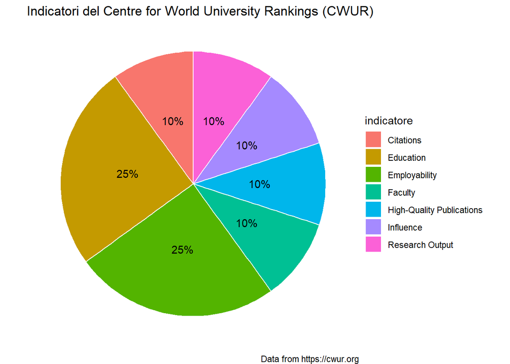

- Academic Ranking of World Universities (ARWU)

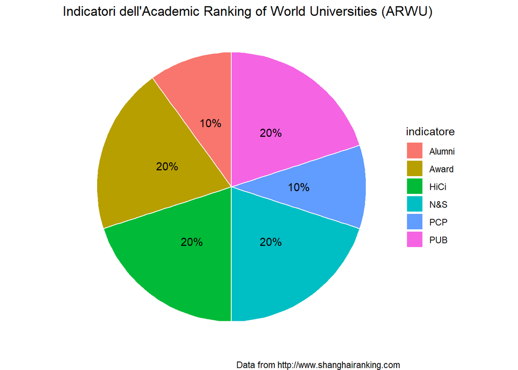

- Times Higher Education World University Ranking

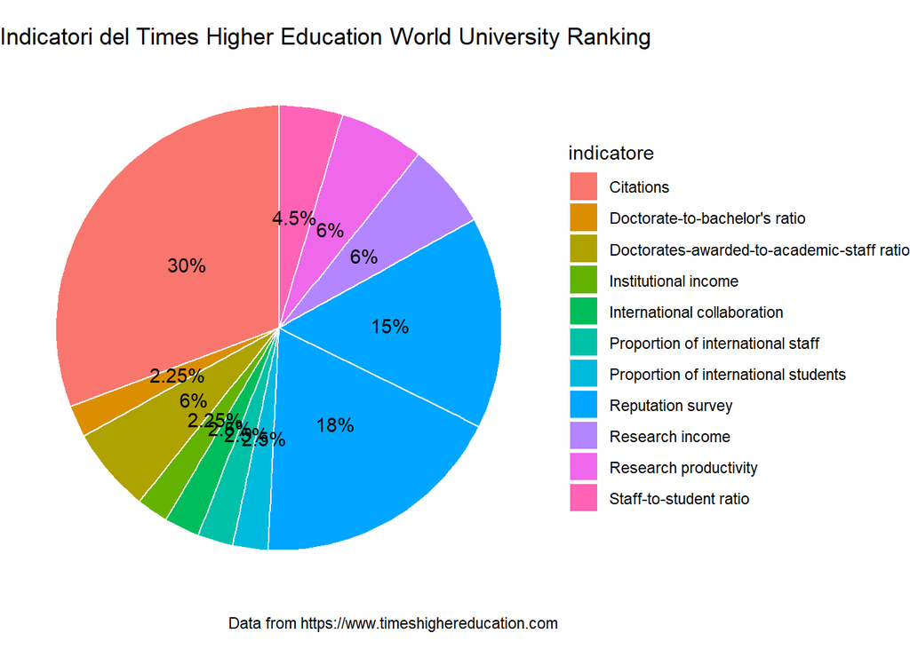

# Quali sono le migliori università …

Analizzando il QS University Ranking si nota che negli ultimi quattro anni, cioè dal 2019 al 2022, le università migliori sono americane o inglesi col primato, per tutti gli anni del MIT

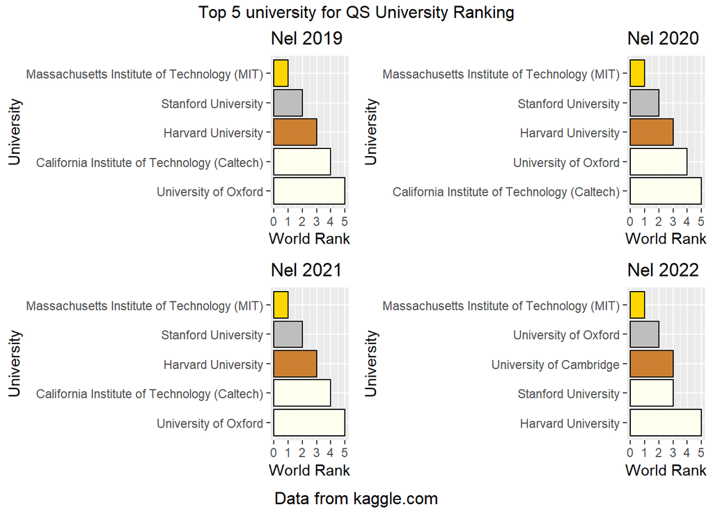

Analizzando il CWUR si ha sempre una prevalenza di americani e inglesi, ma col primato dell’università di Harvard tra il 2012 e il 2015

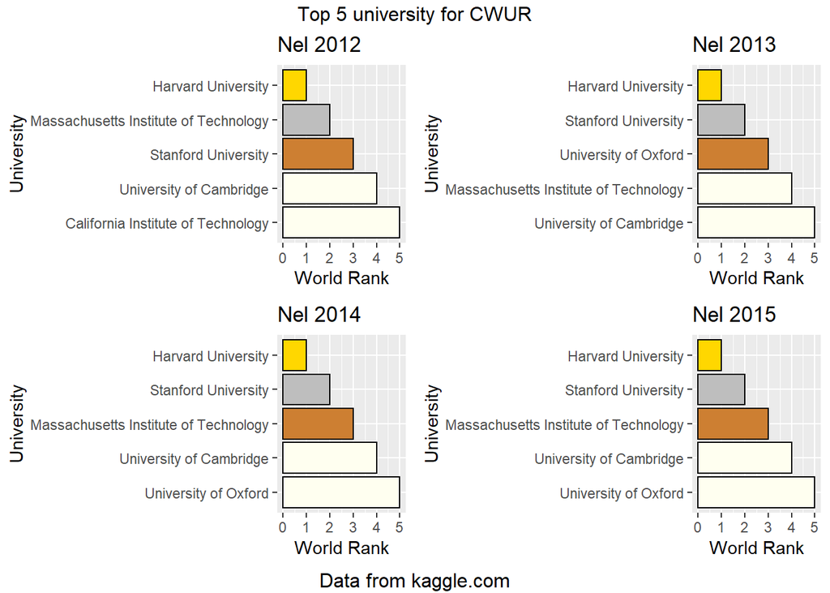

Analizzando il ARWU si ha sempre una prevalenza di americani e inglesi, rimane il primato dell’università di Harvard tra il 2012 e il 2015

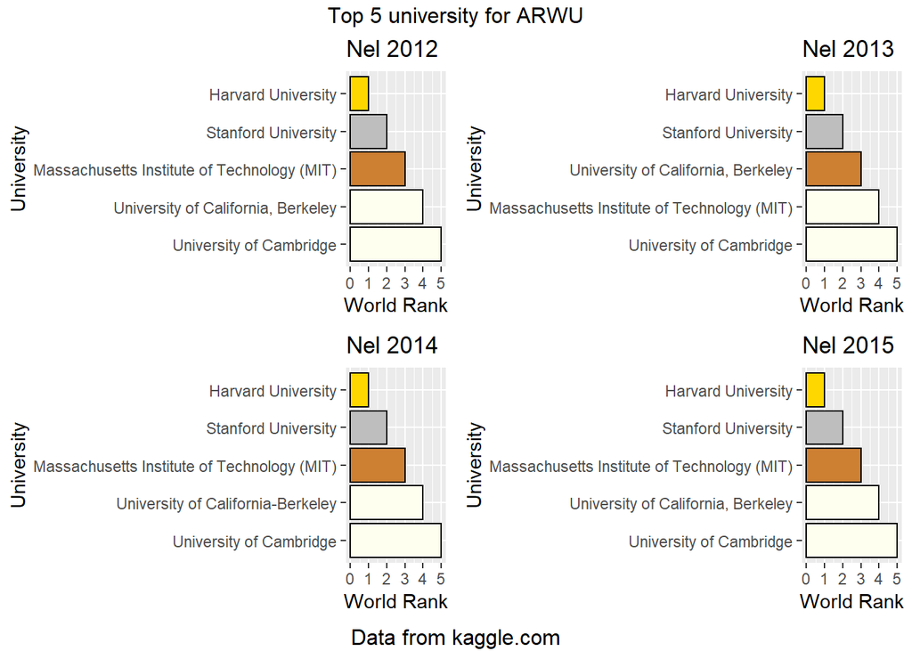

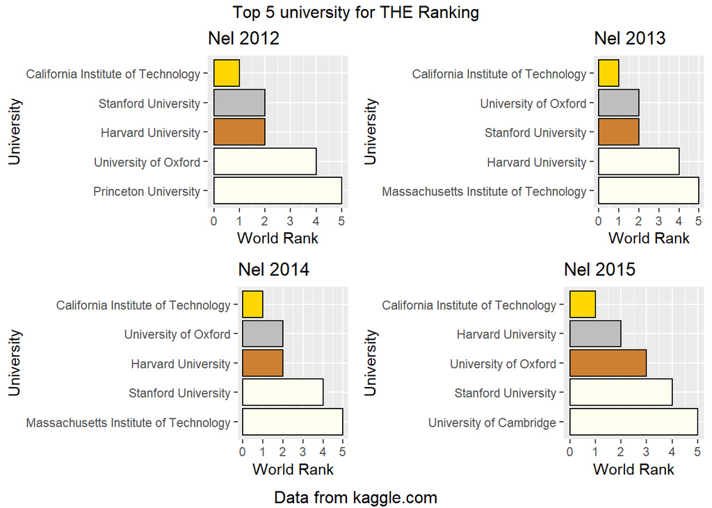

# e i migliori stati?

Si nota analizzando le università che le migliori sono quelle anglo-americane, ma che dire se si raggruppa le università in base allo stato, il loro primato rimane o cambia?

Analizzando il QS University Ranking si nota, tramite la mediana dei valori, che le università inglesi rimangono le migliori mentre quelle tedesche prendono la seconda posizione fino al 2022, dove vengono sostituite da quelle americane

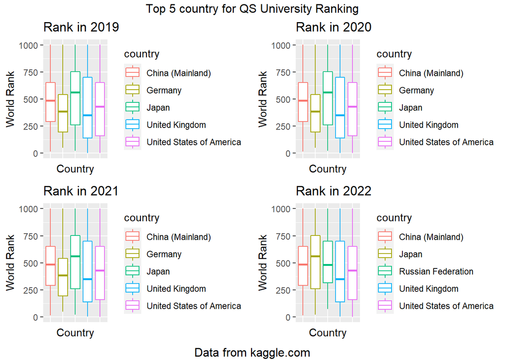

Analizzando il CWUR si nota la presenza con una mediana più bassa di università svizzere e israeliane nel 2012 e 2013 nelle prime posizioni, mentre nel 2014 e 2015 in prima posizione ci sono nuovamente le università americane e inglesi

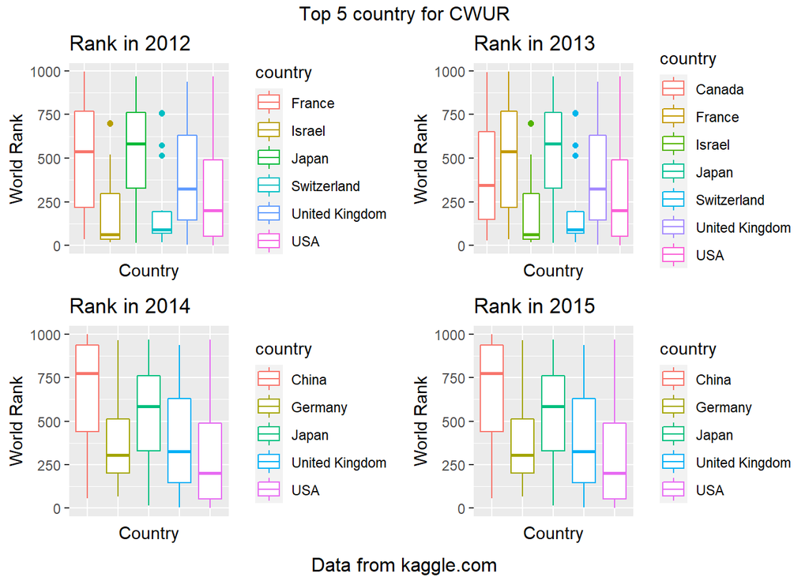

Analizzando il ARWU si ha la conferma del primato americano e inglese in tutti gli anni, si noti però che dal 2014 il distacco tra le prime tre è maggiore degli anni precedenti, in cui la mediana è per lo più simile

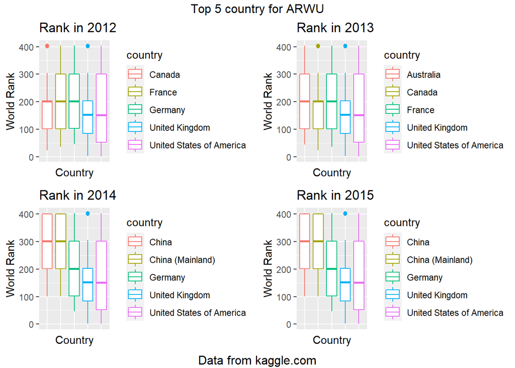

Infine anche l’analisi del THE Ranking da sempre una prevalenza di università americane e inglese, con un andamento per lo più stabile negli anni

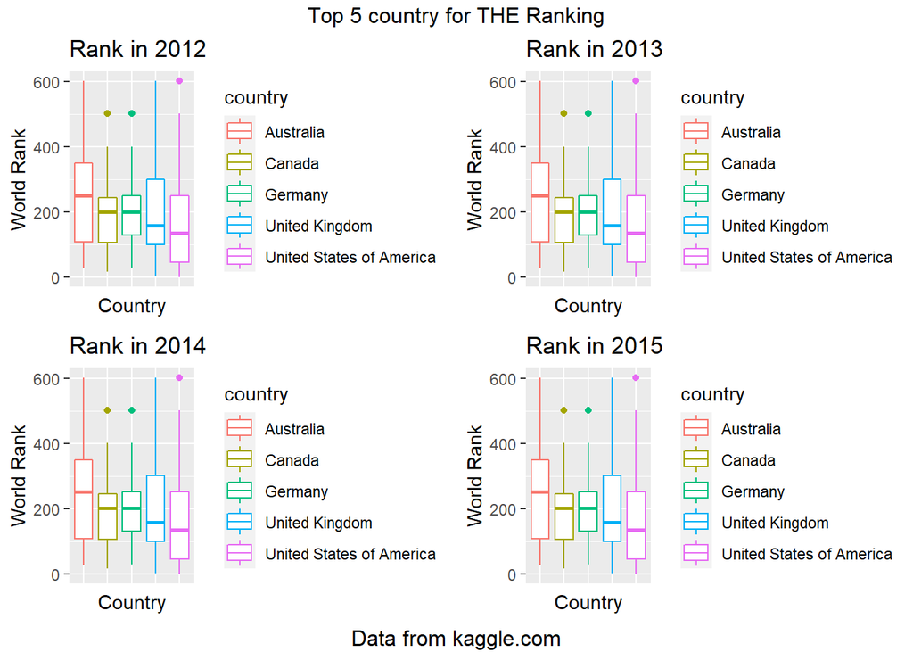

Da questa analisi si nota una conferma da parte di alcuni classifiche del primato delle università inglesi e americane, ma anche la presenza di università di spicco in altri paesi, come Israele, Germania e Giappone

## Ma le università con maggiore score sono davvero quelle migliori?

Dai grafici si nota che le università con il migliore score sono americane o inglesi, analizziamo ora la composizione di questo score totale e quali università sono migliori in un determinato campo Analizzando i dati dei campi per il QS Ranking si nota che mentre presentano un buon punteggio per la maggioranza degli stessi, si nota una leggera mancanza nel campo internazionale, sia dal punto di vista dello staff che degli studenti, mentre il numero delle citazioni è migliorato nel tempo

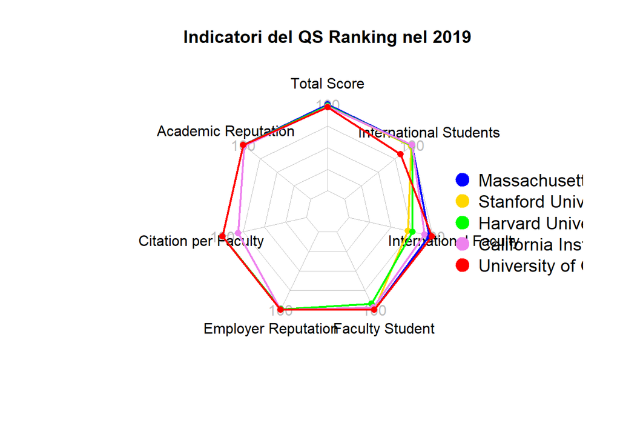

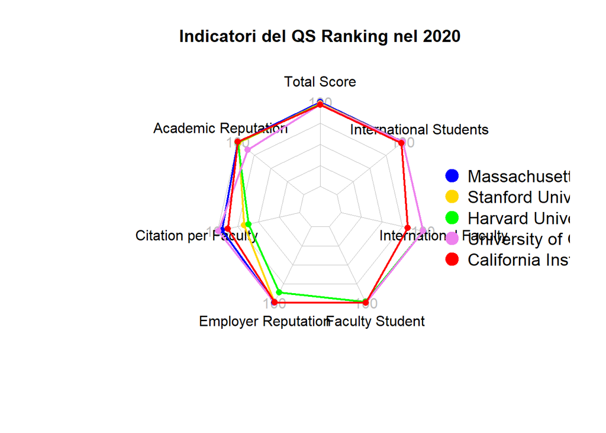

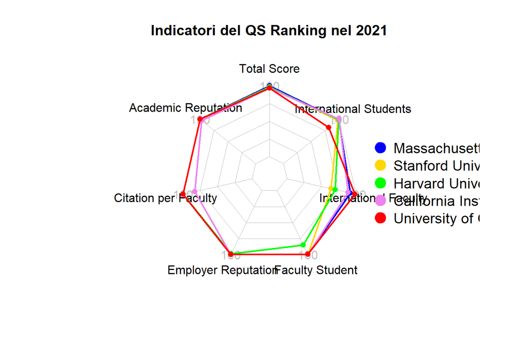

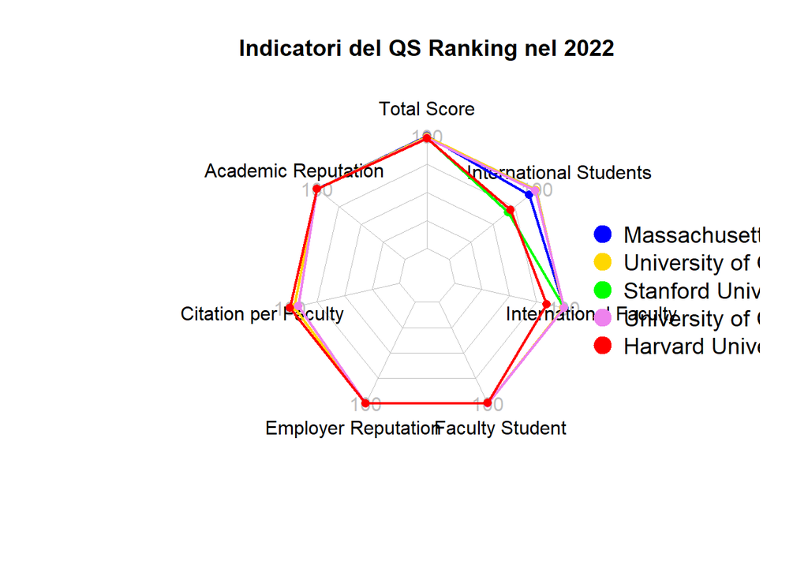

Analizzando i campi del CWUR si nota un punteggio minore rispetto al QS Ranking, infatti solo nel 2012 e solo il California Institute of Technology presenta un punteggio per punti di meno di 40, per poi passare a meno di 20

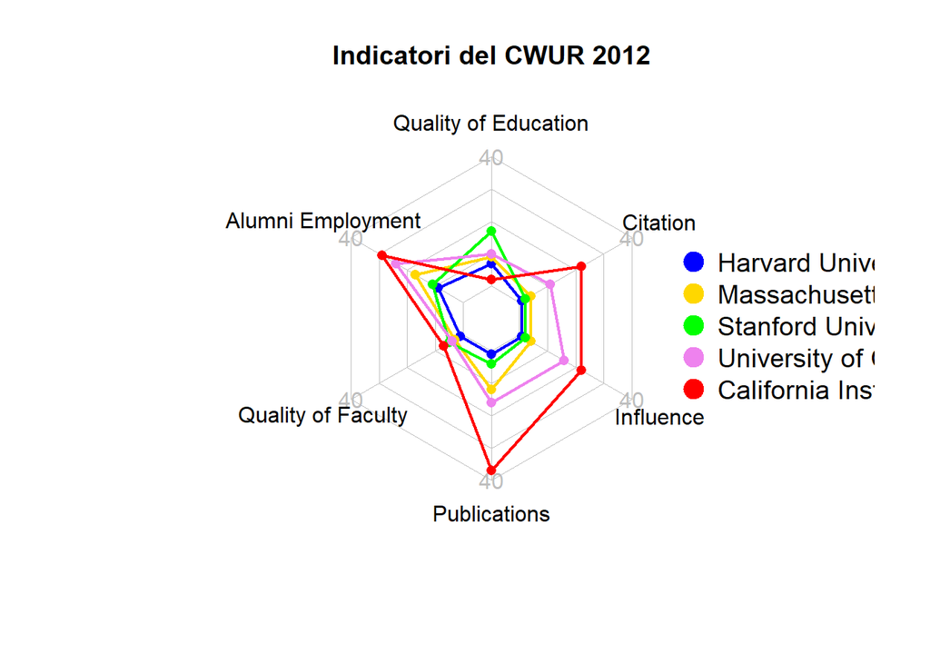

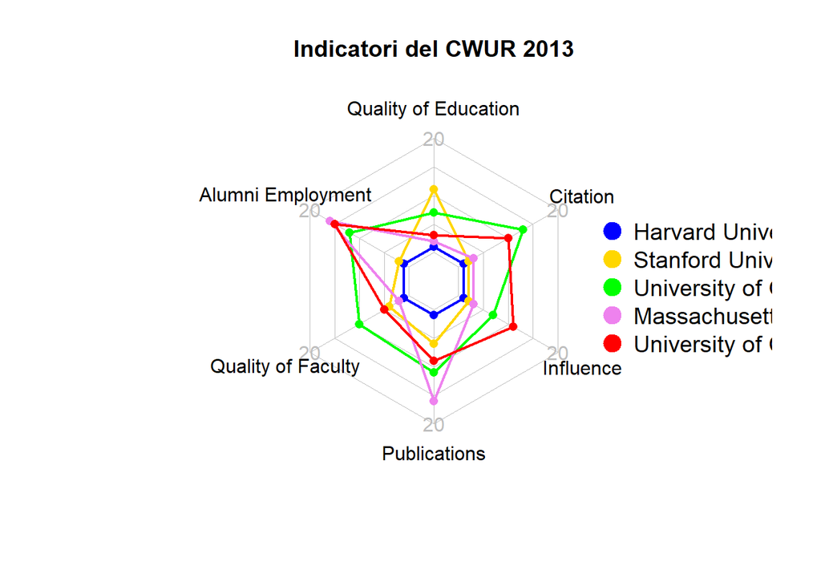

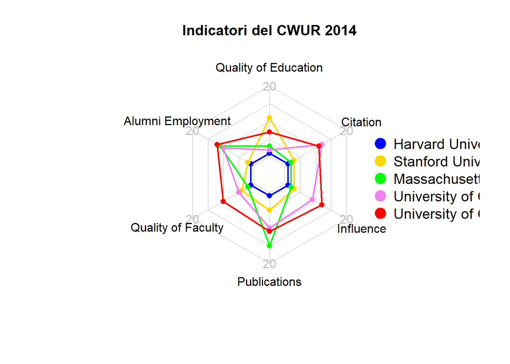

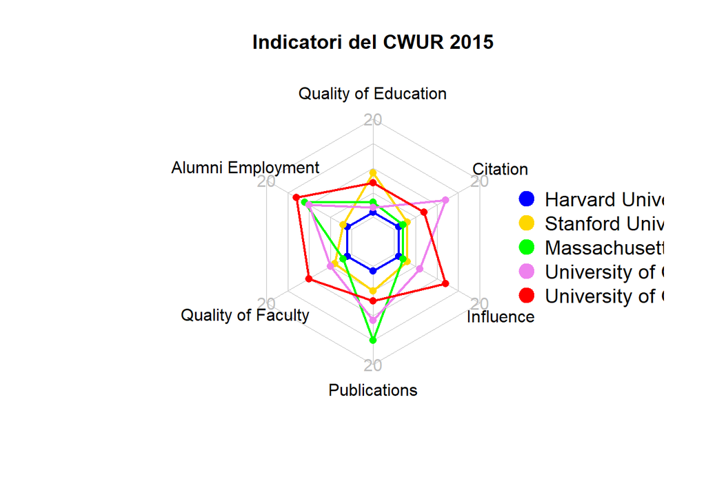

Invece per l’ARWU il punteggio rimane abbastanza stabile nel tempo, con variazioni minimali, e molto alto

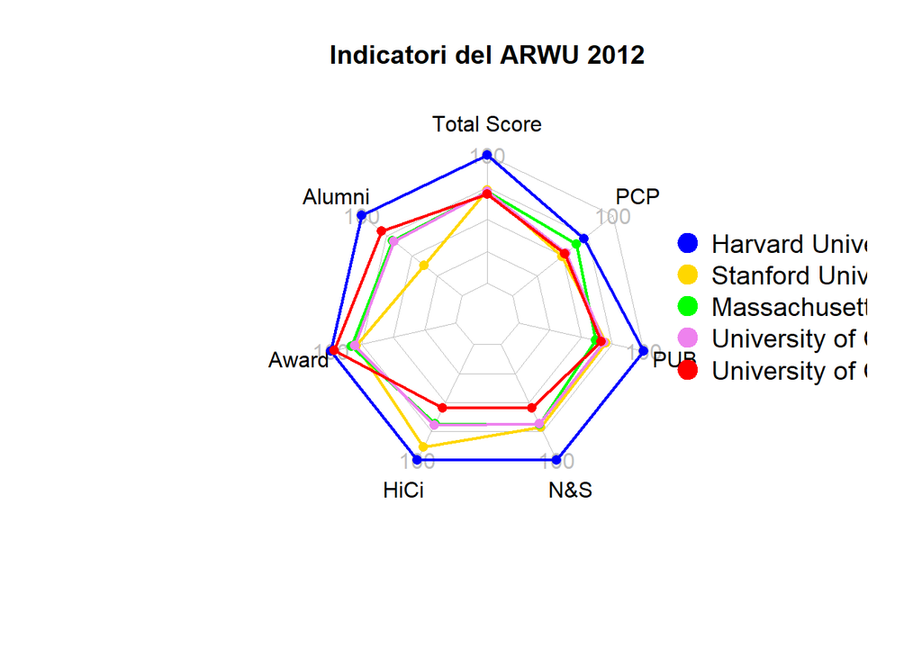

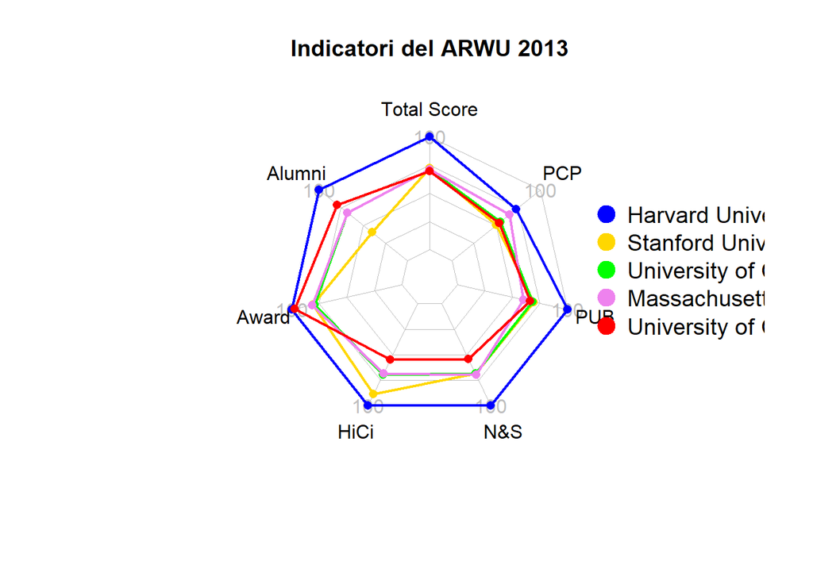

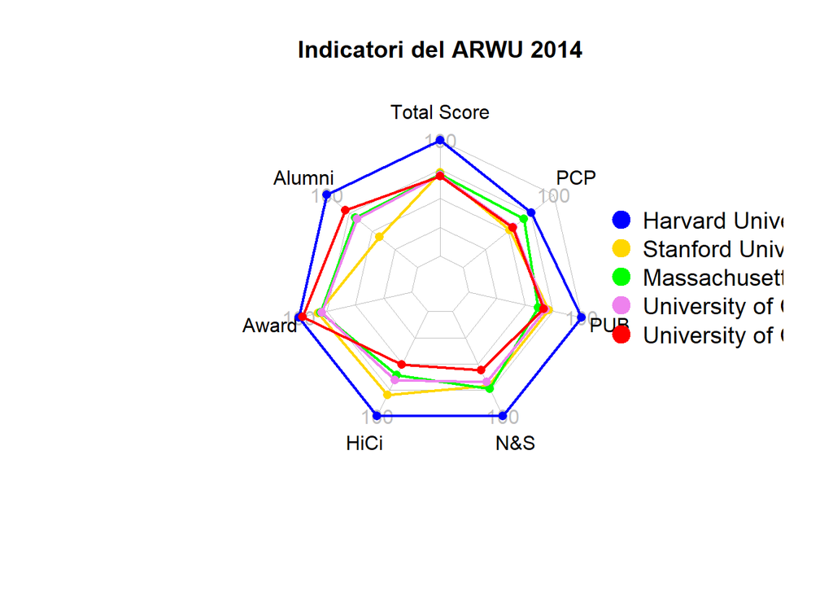

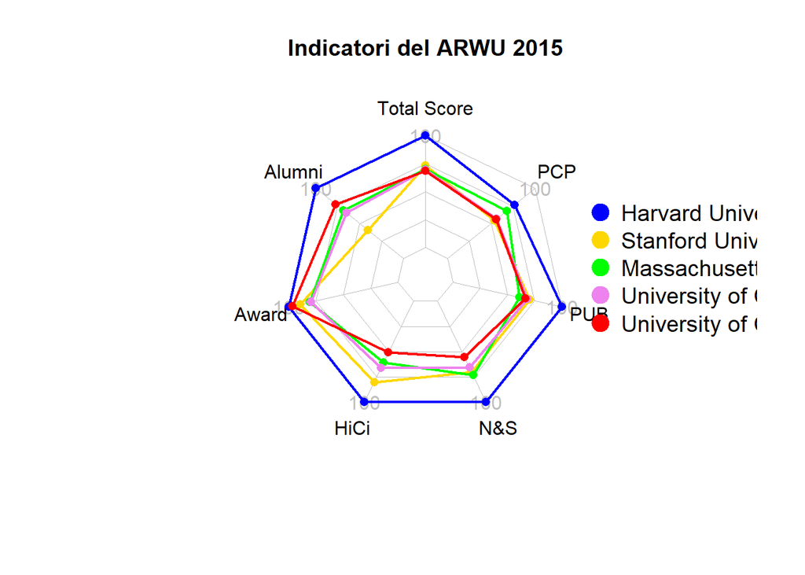

Le variazioni maggiori nelle componenti nel THE Ranking si ha nel punteggio riguardante la prospettiva internazionale, come nel caso del QS Ranking, e l’impatto industriale, mentre le citazioni e la ricerca è abbastanza stabile

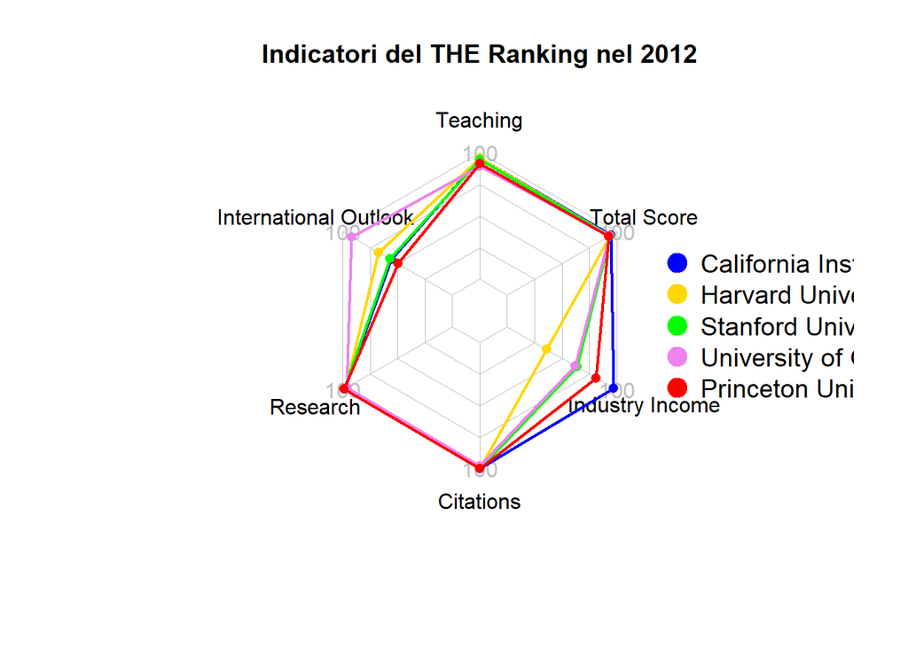

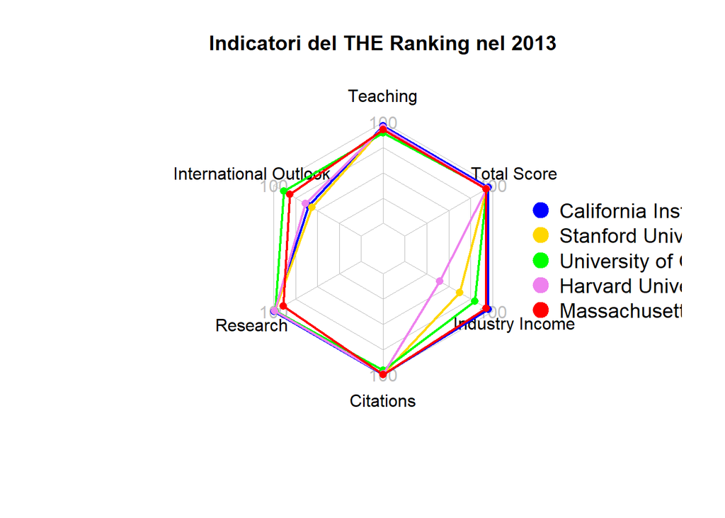

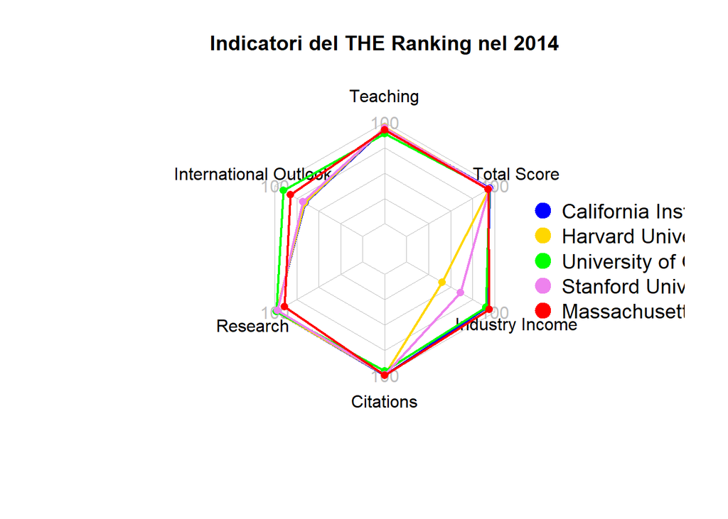

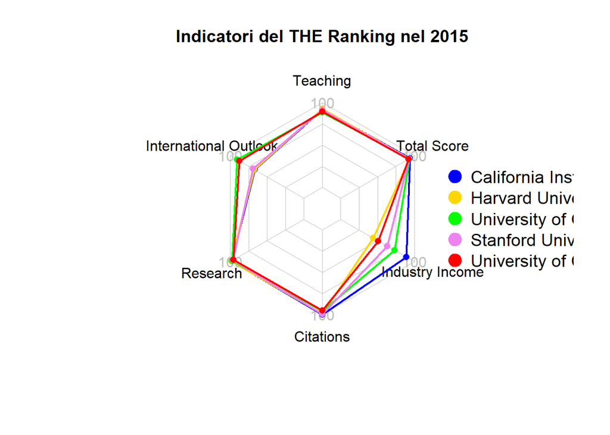

Da questa analisi si nota che nonostante alcuni valori un po’ bassi, le universita top 5 presentano dei punteggi buoni anche nei singoli indicatori

# Correlazione nel ranking

Dalla metodologia usata e illustrata dai diversi ranking si può vedere la correlazione tra lo score e i vari indicatori, ma anche analizzando i dati forniti si può arrivare alla stessa risposta:

- Matrice di correlazione del QS Ranking

[figure not shown]

- Matrice di correlazione del CWUR

[figure not shown]

- Matrice di correlazione dell’ARWU

[figure not shown]

- Matrice di correlazione del THE Ranking

[figure not shown]

# Conclusioni

In conclusione analizzando i dataset si nota una spiccata presenza americana e inglese nella maggioranza dei dataset nonostante l’uso di diversi indicatori, ma dall’analisi si nota anche la presenza di altri paesi, anche inaspettati, come Germania, Israele, Francia e Cina, mentre le università predominanti sono sempre inglesi e americane Da notare invece come nel corso di quattro anni in generale le università non presenta un miglioramento significativo nei singoli parametri utilizzati Quest’analisi può essere usata come spunto per gli studenti per scegliere un’università che presenta delle caratteristiche specifiche, come un alto numero di citazioni o la loro caricatura internazionale, ma anche per le università stesse che possono usarlo come spunto per migliorare gli indicato in cui sono più carenti, come l’impatto dell’università nell’industria per l’università di Harvard, che risulta il suo parametro peggiore in tutti e quattro gli anni analizzati

# Sitografia

- [Kaggle](https://www.kaggle.com/)
- [QS Ranking](https://www.topuniversities.com/)
- [CWUR](https://cwur.org/)
- [ARWU](http://www.shanghairanking.com/)
- [THE Ranking](https://www.timeshighereducation.com/)